# Project: Investigate a TMDb Movies Database

- Introduction
- Data Wrangling
- Exploratory Data Analysis
- Conclusions

## Introduction

In this project, I will focus on investigating the TMDb Movies Database from Kaggle which contains important details of over 10,000 movies such as their genres, runtime, budget, revenue, realease date, etc. There are some questions that will be investigated as follows:

1. Which year has the highest release of movies? How much has the movies industry grown over the years?
2. What is average runtime of movies from year to year?
3. Which movie had the highest and lowest profit?
4. Which movie had the highest and lowest budget? Is there a relationship between profit and budget?
5. How many movies of a particular genre have been released? And how do those release compared over the time?
6. Which genres have the largest revenue and largest budgets? Which genres are most profitable after working out Return on Investment?

To get started, I will import the neccessary libraries to complete the project which are Numpy, Pandas, Matplotlib, Seaborn and then import the csv file named 'tmdb-movies.csv'.

```python
import pandas as pd
import numpy as np
import seaborn as sns
import matplotlib.pyplot as plt
% matplotlib inline

df=pd.read_csv('tmdb-movies.csv')
```

## Data Wrangling

The csv has already been imported, we can now explore the dataset for our futher analysis practice.

### General Properties

```python
# print the first five rows of the entire dataset
df.head(5)
```

|  | id | imdb_id | popularity | budget | revenue | original_title | cast | homepage | director | tagline | ... | overview | runtime | genres | production_companies | release_date | vote_count | vote_average | release_year | budget_adj | revenue_adj |
| --- | --- | --- | --- | --- | --- | --- | --- | --- | --- | --- | --- | --- | --- | --- | --- | --- | --- | --- | --- | --- | --- |
| 0 | 135397 | tt0369610 | 32.985763 | 150000000 | 1513528810 | Jurassic World | Chris Pratt\|Bryce Dallas Howard\|Irrfan Khan\|Vi... | http://www.jurassicworld.com/ | Colin Trevorrow | The park is open. | ... | Twenty-two years after the events of Jurassic ... | 124 | Action\|Adventure\|Science Fiction\|Thriller | Universal Studios\|Amblin Entertainment\|Legenda... | 6/9/15 | 5562 | 6.5 | 2015 | 1.379999e+08 | 1.392446e+09 |
| 1 | 76341 | tt1392190 | 28.419936 | 150000000 | 378436354 | Mad Max: Fury Road | Tom Hardy\|Charlize Theron\|Hugh Keays-Byrne\|Nic... | http://www.madmaxmovie.com/ | George Miller | What a Lovely Day. | ... | An apocalyptic story set in the furthest reach... | 120 | Action\|Adventure\|Science Fiction\|Thriller | Village Roadshow Pictures\|Kennedy Miller Produ... | 5/13/15 | 6185 | 7.1 | 2015 | 1.379999e+08 | 3.481613e+08 |
| 2 | 262500 | tt2908446 | 13.112507 | 110000000 | 295238201 | Insurgent | Shailene Woodley\|Theo James\|Kate Winslet\|Ansel... | http://www.thedivergentseries.movie/#insurgent | Robert Schwentke | One Choice Can Destroy You | ... | Beatrice Prior must confront her inner demons ... | 119 | Adventure\|Science Fiction\|Thriller | Summit Entertainment\|Mandeville Films\|Red Wago... | 3/18/15 | 2480 | 6.3 | 2015 | 1.012000e+08 | 2.716190e+08 |
| 3 | 140607 | tt2488496 | 11.173104 | 200000000 | 2068178225 | Star Wars: The Force Awakens | Harrison Ford\|Mark Hamill\|Carrie Fisher\|Adam D... | http://www.starwars.com/films/star-wars-episod... | J.J. Abrams | Every generation has a story. | ... | Thirty years after defeating the Galactic Empi... | 136 | Action\|Adventure\|Science Fiction\|Fantasy | Lucasfilm\|Truenorth Productions\|Bad Robot | 12/15/15 | 5292 | 7.5 | 2015 | 1.839999e+08 | 1.902723e+09 |
| 4 | 168259 | tt2820852 | 9.335014 | 190000000 | 1506249360 | Furious 7 | Vin Diesel\|Paul Walker\|Jason Statham\|Michelle ... | http://www.furious7.com/ | James Wan | Vengeance Hits Home | ... | Deckard Shaw seeks revenge against Dominic Tor... | 137 | Action\|Crime\|Thriller | Universal Pictures\|Original Film\|Media Rights ... | 4/1/15 | 2947 | 7.3 | 2015 | 1.747999e+08 | 1.385749e+09 |

5 rows × 21 columns

```python
# print the last two rows of the entire dataset
df.tail(2)
```

|  | id | imdb_id | popularity | budget | revenue | original_title | cast | homepage | director | tagline | ... | overview | runtime | genres | production_companies | release_date | vote_count | vote_average | release_year | budget_adj | revenue_adj |
| --- | --- | --- | --- | --- | --- | --- | --- | --- | --- | --- | --- | --- | --- | --- | --- | --- | --- | --- | --- | --- | --- |
| 10864 | 21449 | tt0061177 | 0.064317 | 0 | 0 | What's Up, Tiger Lily? | Tatsuya Mihashi\|Akiko Wakabayashi\|Mie Hama\|Joh... | NaN | Woody Allen | WOODY ALLEN STRIKES BACK! | ... | In comic Woody Allen's film debut, he took the... | 80 | Action\|Comedy | Benedict Pictures Corp. | 11/2/66 | 22 | 5.4 | 1966 | 0.000000 | 0.0 |
| 10865 | 22293 | tt0060666 | 0.035919 | 19000 | 0 | Manos: The Hands of Fate | Harold P. Warren\|Tom Neyman\|John Reynolds\|Dian... | NaN | Harold P. Warren | It's Shocking! It's Beyond Your Imagination! | ... | A family gets lost on the road and stumbles up... | 74 | Horror | Norm-Iris | 11/15/66 | 15 | 1.5 | 1966 | 127642.279154 | 0.0 |

2 rows × 21 columns

```python
# print the concise sumary of the dataset to examine the datasettypes associated with each column
# and the total number of non-null values per column
df.info()
```

```
<class 'pandas.core.frame.DataFrame'>
RangeIndex: 10866 entries, 0 to 10865
Data columns (total 21 columns):
id                      10866 non-null int64
imdb_id                 10856 non-null object
popularity              10866 non-null float64
budget                  10866 non-null int64
revenue                 10866 non-null int64
original_title          10866 non-null object
cast                    10790 non-null object
homepage                2936 non-null object
director                10822 non-null object
tagline                 8042 non-null object
keywords                9373 non-null object
overview                10862 non-null object
runtime                 10866 non-null int64
genres                  10843 non-null object
production_companies    9836 non-null object
release_date            10866 non-null object
vote_count              10866 non-null int64
vote_average            10866 non-null float64
release_year            10866 non-null int64
budget_adj              10866 non-null float64
revenue_adj             10866 non-null float64
dtypes: float64(4), int64(6), object(11)
memory usage: 1.7+ MB
```

```python
# As we can see above the dataset contain the null values
# let's count the total rows in each columns which contain null values
df.isnull().sum()
```

```
id                         0
imdb_id                   10
popularity                 0
budget                     0
revenue                    0
original_title             0
cast                      76
homepage                7930
director                  44
tagline                 2824
keywords                1493
overview                   4
runtime                    0
genres                    23
production_companies    1030
release_date               0
vote_count                 0
vote_average               0
release_year               0
budget_adj                 0
revenue_adj                0
dtype: int64
```

```python
# examine the basic statistics of the dataset such as min, max, mean,etc..
df.describe()
```

|  | id | popularity | budget | revenue | runtime | vote_count | vote_average | release_year | budget_adj | revenue_adj |
| --- | --- | --- | --- | --- | --- | --- | --- | --- | --- | --- |
| count | 10866.000000 | 10866.000000 | 1.086600e+04 | 1.086600e+04 | 10866.000000 | 10866.000000 | 10866.000000 | 10866.000000 | 1.086600e+04 | 1.086600e+04 |
| mean | 66064.177434 | 0.646441 | 1.462570e+07 | 3.982332e+07 | 102.070863 | 217.389748 | 5.974922 | 2001.322658 | 1.755104e+07 | 5.136436e+07 |
| std | 92130.136561 | 1.000185 | 3.091321e+07 | 1.170035e+08 | 31.381405 | 575.619058 | 0.935142 | 12.812941 | 3.430616e+07 | 1.446325e+08 |
| min | 5.000000 | 0.000065 | 0.000000e+00 | 0.000000e+00 | 0.000000 | 10.000000 | 1.500000 | 1960.000000 | 0.000000e+00 | 0.000000e+00 |
| 25% | 10596.250000 | 0.207583 | 0.000000e+00 | 0.000000e+00 | 90.000000 | 17.000000 | 5.400000 | 1995.000000 | 0.000000e+00 | 0.000000e+00 |
| 50% | 20669.000000 | 0.383856 | 0.000000e+00 | 0.000000e+00 | 99.000000 | 38.000000 | 6.000000 | 2006.000000 | 0.000000e+00 | 0.000000e+00 |
| 75% | 75610.000000 | 0.713817 | 1.500000e+07 | 2.400000e+07 | 111.000000 | 145.750000 | 6.600000 | 2011.000000 | 2.085325e+07 | 3.369710e+07 |
| max | 417859.000000 | 32.985763 | 4.250000e+08 | 2.781506e+09 | 900.000000 | 9767.000000 | 9.200000 | 2015.000000 | 4.250000e+08 | 2.827124e+09 |

**Observation:** It was noticed from the above result that some of the values under study were showing odd values. For example, the budget, revenue and runtime columns had a min value of 0 which is an unusual occurence.

```python
# total of duplicate rows in the dataset
df.duplicated().sum()
```

```
1
```

```python
# number of non-null unique values for features in the dataset
df.nunique()
```

```
id                      10865
imdb_id                 10855
popularity              10814
budget                    557
revenue                  4702
original_title          10571
cast                    10719
homepage                 2896
director                 5067
tagline                  7997
keywords                 8804
overview                10847
runtime                   247
genres                   2039
production_companies     7445
release_date             5909
vote_count               1289
vote_average               72
release_year               56
budget_adj               2614
revenue_adj              4840
dtype: int64
```

## Data Cleaning

In this part, we need to remove or modify some features in the dataset in the following ways:

1. Drop the unused colums that are not necessary in the analysis process
2. Fill rows with missing values
3. Drop any duplicated rows
4. Replace zero value in budget, revenue, runtime

### Drop Extraneous Columns

```python
# drop columns from 2018 dataset
df.drop(['imdb_id','cast','homepage','tagline','overview','budget_adj','revenue_adj'], axis=1, inplace=True)
# confirm change
df.head(1)
```

|  | id | popularity | budget | revenue | original_title | director | keywords | runtime | genres | production_companies | release_date | vote_count | vote_average | release_year |
| --- | --- | --- | --- | --- | --- | --- | --- | --- | --- | --- | --- | --- | --- | --- |
| 0 | 135397 | 32.985763 | 150000000 | 1513528810 | Jurassic World | Colin Trevorrow | monster\|dna\|tyrannosaurus rex\|velociraptor\|island | 124 | Action\|Adventure\|Science Fiction\|Thriller | Universal Studios\|Amblin Entertainment\|Legenda... | 6/9/15 | 5562 | 6.5 | 2015 |

### Fill Rows with Missing Values

```python
# view missing value count for each feature
df.isnull().sum()
```

```
id                         0
popularity                 0
budget                     0
revenue                    0
original_title             0
director                  44
keywords                1493
runtime                    0
genres                    23
production_companies    1030
release_date               0
vote_count                 0
vote_average               0
release_year               0
dtype: int64
```

```python
# fill the null value with zero using 'fillna' function
df=df.fillna(0)
```

```python
# checks if any of columns in the dataset have null values - should print False
df.isnull().sum().any()
```

```
False
```

### Drop Duplicate Rows

```python
# print number of duplicates in the datasets
print(df.duplicated().sum())
```

```
1
```

```python
# drop duplicates
df.drop_duplicates(inplace=True)
```

```python
# print number of duplicates again to confirm dedupe - should both be 0
print(df.duplicated().sum())
```

```
0
```

### Replace Zero Values

During the wrangling process, it was noticed that some of the values under study were showing odd values. For example, the budget, revenue and runtime columns had a min value of 0 which is an unusual occurence. Therefore, I will convert them to null values.

```python
# check zero values in budget
df_budget=df.loc[(df[['budget']] == 0).all(axis=1)]
df_budget.head(1)
```

|  | id | popularity | budget | revenue | original_title | director | keywords | runtime | genres | production_companies | release_date | vote_count | vote_average | release_year |
| --- | --- | --- | --- | --- | --- | --- | --- | --- | --- | --- | --- | --- | --- | --- |
| 30 | 280996 | 3.927333 | 0 | 29355203 | Mr. Holmes | Bill Condon | london\|detective\|sherlock holmes | 103 | Mystery\|Drama | BBC Films\|See-Saw Films\|FilmNation Entertainme... | 6/19/15 | 425 | 6.4 | 2015 |

As we can see, the movie **Mr.Holmes** has the budget of 0; however, it does not make sense since it has an estimated budget of $10,000,000.00 based on IMDB. Thus, this value is unreliable

```python
# check zero values in revenue
df_revenue=df.loc[(df[['revenue']] == 0).all(axis=1)]
df_revenue.sample(1)
```

|  | id | popularity | budget | revenue | original_title | director | keywords | runtime | genres | production_companies | release_date | vote_count | vote_average | release_year |
| --- | --- | --- | --- | --- | --- | --- | --- | --- | --- | --- | --- | --- | --- | --- |
| 10792 | 12237 | 0.232879 | 0 | 0 | Faces of Death | John Alan Schwartz | suicide\|doomed man\|dying and death\|autopsy\|dea... | 105 | Documentary\|Horror | F.O.D. Productions | 1/1/78 | 16 | 4.7 | 1978 |

```python
# check zero values in runtime
df_runtime=df.loc[(df[['runtime']]==0).all(axis=1)]
df_runtime.tail(1)
```

|  | id | popularity | budget | revenue | original_title | director | keywords | runtime | genres | production_companies | release_date | vote_count | vote_average | release_year |
| --- | --- | --- | --- | --- | --- | --- | --- | --- | --- | --- | --- | --- | --- | --- |
| 8874 | 46406 | 0.069903 | 0 | 0 | Mission Kashmir | Vidhu Vinod Chopra | 0 | 0 | Action\|Drama\|Foreign | 0 | 10/27/00 | 10 | 5.7 | 2000 |

We noticed that the values displayed under these columns are incorrect. In order to maintain record of the remaining columns which may need to use for analysis in other questions, it's better to replace those zero values with null values.

```python
# replace zero values with null values
cols=['budget','revenue','runtime']
df[cols]=df[cols].replace(0,np.nan)
# check result
df.describe()
```

|  | id | popularity | budget | revenue | runtime | vote_count | vote_average | release_year |
| --- | --- | --- | --- | --- | --- | --- | --- | --- |
| count | 10865.000000 | 10865.000000 | 5.169000e+03 | 4.849000e+03 | 10834.000000 | 10865.000000 | 10865.000000 | 10865.000000 |
| mean | 66066.374413 | 0.646446 | 3.073958e+07 | 8.923886e+07 | 102.363855 | 217.399632 | 5.975012 | 2001.321859 |
| std | 92134.091971 | 1.000231 | 3.890441e+07 | 1.620801e+08 | 30.948225 | 575.644627 | 0.935138 | 12.813260 |
| min | 5.000000 | 0.000065 | 1.000000e+00 | 2.000000e+00 | 2.000000 | 10.000000 | 1.500000 | 1960.000000 |
| 25% | 10596.000000 | 0.207575 | 6.000000e+06 | 7.732325e+06 | 90.000000 | 17.000000 | 5.400000 | 1995.000000 |
| 50% | 20662.000000 | 0.383831 | 1.700000e+07 | 3.185308e+07 | 99.000000 | 38.000000 | 6.000000 | 2006.000000 |
| 75% | 75612.000000 | 0.713857 | 4.000000e+07 | 9.996575e+07 | 112.000000 | 146.000000 | 6.600000 | 2011.000000 |
| max | 417859.000000 | 32.985763 | 4.250000e+08 | 2.781506e+09 | 900.000000 | 9767.000000 | 9.200000 | 2015.000000 |

```python
# confirm changes again
df.info()
```

```
<class 'pandas.core.frame.DataFrame'>
Int64Index: 10865 entries, 0 to 10865
Data columns (total 14 columns):
id                      10865 non-null int64
popularity              10865 non-null float64
budget                  5169 non-null float64
revenue                 4849 non-null float64
original_title          10865 non-null object
director                10865 non-null object
keywords                10865 non-null object
runtime                 10834 non-null float64
genres                  10865 non-null object
production_companies    10865 non-null object
release_date            10865 non-null object
vote_count              10865 non-null int64
vote_average            10865 non-null float64
release_year            10865 non-null int64
dtypes: float64(5), int64(3), object(6)
memory usage: 1.2+ MB
```

## Exploratory Data Analysis

### Research Question 1: Which year has the highest release of movies? How much has the movies industry grown over the years?

Let's look at number of the movies for each year

```python
# make group for each year and count the number of movies in each year
year=df.groupby('release_year').count()['id']
year.tail(5)
```

```
release_year
2011    540
2012    588
2013    659
2014    700
2015    629
Name: id, dtype: int64
```

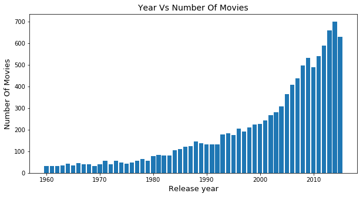

```python
# plot
plt.subplots(figsize=(10,5))
plt.bar(year.index, year)
plt.title('Year Vs Number Of Movies',fontsize = 14)
plt.xlabel('Release year',fontsize = 13)
plt.ylabel('Number Of Movies',fontsize = 13);
```

**According to the above result,** we can see that year 2014 has the highest release of movies (700) followed by year 2013 (659) and year 2015 (629). The movie industry has been growing exponentially over the past half a century with an immense growth starting from the 1990s.

### Research Question 2 : What is average runtime of movies from year to year?

```python
# # make group for each year and find the mean of runtime
avr_runtime=df.groupby('release_year').mean()['runtime']
avr_runtime.head(5)
```

```
release_year
1960    110.656250
1961    119.419355
1962    124.343750
1963    111.323529
1964    109.214286
Name: runtime, dtype: float64
```

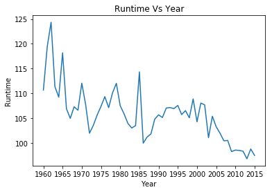

```python
# plot
avr_runtime.plot(xticks = np.arange(1960,2016,5))
#setup the figure size.
sns.set(rc={'figure.figsize':(10,5)})
plt.title("Runtime Vs Year")
plt.xlabel('Year')
plt.ylabel('Runtime')
sns.set_style("whitegrid")
```

**According to the plot,** the average runtime of movies has been dcreasing from year to year. After the year 1985, the average runtime duraion of the movies are around 100 minutes and tend to be lower. This is true fact since nobody wants to watch the long duration movies

### Research Question 3 : Which movie had the highest and lowest profit?

We first need to calculate profit and add to a new column

```python
# To calculate profit, we substract the budget from the revenue.
df['profit'] = df['revenue'] - df['budget']
# Lets look at the new dataset
df.head(1)
```

|  | id | popularity | budget | revenue | original_title | director | keywords | runtime | genres | production_companies | release_date | vote_count | vote_average | release_year | profit |
| --- | --- | --- | --- | --- | --- | --- | --- | --- | --- | --- | --- | --- | --- | --- | --- |
| 0 | 135397 | 32.985763 | 150000000.0 | 1.513529e+09 | Jurassic World | Colin Trevorrow | monster\|dna\|tyrannosaurus rex\|velociraptor\|island | 124.0 | Action\|Adventure\|Science Fiction\|Thriller | Universal Studios\|Amblin Entertainment\|Legenda... | 6/9/15 | 5562 | 6.5 | 2015 | 1.363529e+09 |

```python
# Movie with highest profit
df.loc[df['profit'].idxmax()]
```

```
id                                                                  19995
popularity                                                        9.43277
budget                                                           2.37e+08
revenue                                                       2.78151e+09
original_title                                                     Avatar
director                                                    James Cameron
keywords                culture clash|future|space war|space colony|so...
runtime                                                               162
genres                           Action|Adventure|Fantasy|Science Fiction
production_companies    Ingenious Film Partners|Twentieth Century Fox ...
release_date                                                     12/10/09
vote_count                                                           8458
vote_average                                                          7.1
release_year                                                         2009
profit                                                        2.54451e+09
Name: 1386, dtype: object
```

```python
# Movie with lowest profit
df.loc[df['profit'].idxmin()]
```

```
id                                                                  46528
popularity                                                        0.25054
budget                                                           4.25e+08
revenue                                                       1.10876e+07
original_title                                          The Warrior's Way
director                                                       Sngmoo Lee
keywords                assassin|small town|revenge|deception|super speed
runtime                                                               100
genres                          Adventure|Fantasy|Action|Western|Thriller
production_companies                             Boram Entertainment Inc.
release_date                                                      12/2/10
vote_count                                                             74
vote_average                                                          6.4
release_year                                                         2010
profit                                                       -4.13912e+08
Name: 2244, dtype: object
```

**Based on the above result, we can conclude that:**

- Movie has the highest profits is Avatar with profit of 2.5445 billion dollars
- Movie has the lowest profits is The Warrior's Way with profit of - 413 million dollars

### Research Question 4 : Which movie had the highest and lowest budget? Is there a relationship between profit and budget?

```python
# Movie with highest budget
df.loc[df['budget'].idxmax()]
```

```
id                                                                  46528
popularity                                                        0.25054
budget                                                           4.25e+08
revenue                                                       1.10876e+07
original_title                                          The Warrior's Way
director                                                       Sngmoo Lee
keywords                assassin|small town|revenge|deception|super speed
runtime                                                               100
genres                          Adventure|Fantasy|Action|Western|Thriller
production_companies                             Boram Entertainment Inc.
release_date                                                      12/2/10
vote_count                                                             74
vote_average                                                          6.4
release_year                                                         2010
profit                                                       -4.13912e+08
Name: 2244, dtype: object
```

```python
# Movie with highest budget
df.loc[df['budget'].idxmin()]
```

```
id                                                                 287524
popularity                                                       0.177102
budget                                                                  1
revenue                                                               NaN
original_title                                                Fear Clinic
director                                                      Robert Hall
keywords                                               phobia|doctor|fear
runtime                                                                95
genres                                                             Horror
production_companies    Dry County Films|Anchor Bay Entertainment|Movi...
release_date                                                     10/31/14
vote_count                                                             15
vote_average                                                          4.1
release_year                                                         2014
profit                                                                NaN
Name: 1151, dtype: object
```

**As we can from the result:**

- Movie has the highest budget is The Warrior's Way
- Movie has the lowest budget is Fear Clinic

*Now let's check if there is a relationship between budget and profit*

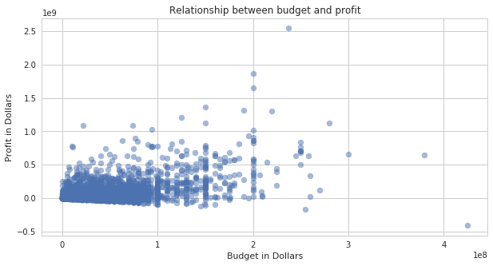

```python
plt.xlabel('Budget in Dollars')
plt.ylabel('Profit in Dollars')
plt.title('Relationship between budget and profit')
plt.scatter(df['budget'], df['profit'], alpha=0.5)
plt.show()
```

```python
#find the correlation using 'corr()' function.
#it returns a dataframe which contain the correlation between all the numeric columns.
data_corr=df.corr()
data_corr.loc['profit','budget']
```

```
0.52681765399240565
```

Profit And Budget both have positive correlation (0.53) between them. It means that there is a good possibility that movies with higher investments result in better profit.

### Research Question 5 : How many movies of a particular genre have been released? And how do those release compared over the time?

```python
# First of all, let's take a look at the unique genres column
df['genres'].unique()
```

```
array(['Action|Adventure|Science Fiction|Thriller',
       'Adventure|Science Fiction|Thriller',
       'Action|Adventure|Science Fiction|Fantasy', ...,
       'Adventure|Drama|Action|Family|Foreign',
       'Comedy|Family|Mystery|Romance',
       'Mystery|Science Fiction|Thriller|Drama'], dtype=object)
```

```python
# count the number of unique genres
df['genres'].nunique()
```

```
2040
```

Due to genres column containing multiple values separated by pipe (|), there are way too many unique points. To resolve this, we will need to segregate the values under genre by splitting them from the pipes and creating a new unique row for each genre.

```python
genres_split = df['genres'].str.split('|').apply(pd.Series, 1).stack()
genres_split.index = genres_split.index.droplevel(-1)
genres_split.name = 'genres'

del df['genres']

df_genres = df.join(genres_split)

df_genres.head()
```

|  | id | popularity | budget | revenue | original_title | director | keywords | runtime | production_companies | release_date | vote_count | vote_average | release_year | profit | genres |
| --- | --- | --- | --- | --- | --- | --- | --- | --- | --- | --- | --- | --- | --- | --- | --- |
| 0 | 135397 | 32.985763 | 150000000.0 | 1.513529e+09 | Jurassic World | Colin Trevorrow | monster\|dna\|tyrannosaurus rex\|velociraptor\|island | 124.0 | Universal Studios\|Amblin Entertainment\|Legenda... | 6/9/15 | 5562 | 6.5 | 2015 | 1.363529e+09 | Action |
| 0 | 135397 | 32.985763 | 150000000.0 | 1.513529e+09 | Jurassic World | Colin Trevorrow | monster\|dna\|tyrannosaurus rex\|velociraptor\|island | 124.0 | Universal Studios\|Amblin Entertainment\|Legenda... | 6/9/15 | 5562 | 6.5 | 2015 | 1.363529e+09 | Adventure |
| 0 | 135397 | 32.985763 | 150000000.0 | 1.513529e+09 | Jurassic World | Colin Trevorrow | monster\|dna\|tyrannosaurus rex\|velociraptor\|island | 124.0 | Universal Studios\|Amblin Entertainment\|Legenda... | 6/9/15 | 5562 | 6.5 | 2015 | 1.363529e+09 | Science Fiction |
| 0 | 135397 | 32.985763 | 150000000.0 | 1.513529e+09 | Jurassic World | Colin Trevorrow | monster\|dna\|tyrannosaurus rex\|velociraptor\|island | 124.0 | Universal Studios\|Amblin Entertainment\|Legenda... | 6/9/15 | 5562 | 6.5 | 2015 | 1.363529e+09 | Thriller |
| 1 | 76341 | 28.419936 | 150000000.0 | 3.784364e+08 | Mad Max: Fury Road | George Miller | future\|chase\|post-apocalyptic\|dystopia\|australia | 120.0 | Village Roadshow Pictures\|Kennedy Miller Produ... | 5/13/15 | 6185 | 7.1 | 2015 | 2.284364e+08 | Action |

Now lets count the number of movies aggregated by each genre over the years using the groupby function, assign it to a new dataframe and view the results

```python
# let's see total movies by each genres
df_genres_count=df_genres.groupby(['genres']).count()['id'].sort_values(ascending=False)
df_genres_count
```

```
genres
Drama              4760
Comedy             3793
Thriller           2907
Action             2384
Romance            1712
Horror             1637
Adventure          1471
Crime              1354
Family             1231
Science Fiction    1229
Fantasy             916
Mystery             810
Animation           699
Documentary         520
Music               408
History             334
War                 270
Foreign             188
TV Movie            167
Western             165
Name: id, dtype: int64
```

Now, let's plot to get better view of the number of release for each genre

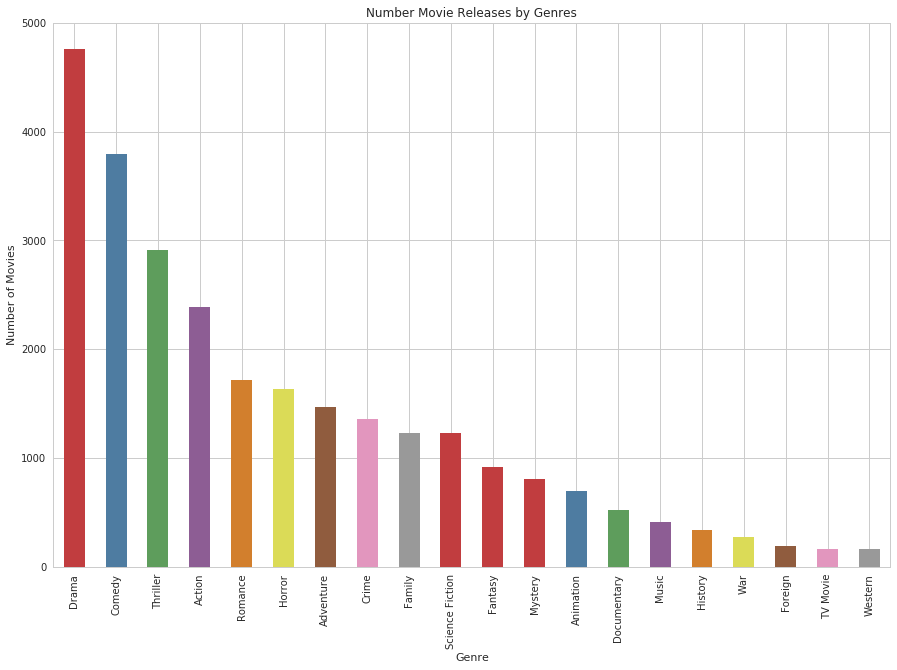

```python
sns.set_style('whitegrid')

# plot data
fig, ax = plt.subplots(figsize=(15,10))

sns.set_palette("Set1", 10, .65)

# use unstack()
df_genres_count.plot(kind="bar",  ax=ax);
ax.set(xlabel='Genre', ylabel='Number of Movies', title = 'Number Movie Releases by Genres');
```

**According to the plot Drama genre has the highest release of movies (4760) followed by Comedy (3793) and Thriller(2907).**

We now have our genre types, we have our total releases - but how do those releases compare over time? Lets group by release year and genre, and compare using an area chart

```python
# let's see number of movies groupby each release year and genres
df_genres_year=df_genres.groupby(['release_year','genres']).count()['id'].unstack()
# confirm
df_genres_year.tail(5)
```

| genres release_year | Action | Adventure | Animation | Comedy | Crime | Documentary | Drama | Family | Fantasy | Foreign | History | Horror | Music | Mystery | Romance | Science Fiction | TV Movie | Thriller | War | Western |
| --- | --- | --- | --- | --- | --- | --- | --- | --- | --- | --- | --- | --- | --- | --- | --- | --- | --- | --- | --- | --- |
| 2011 | 115.0 | 62.0 | 46.0 | 172.0 | 48.0 | 49.0 | 214.0 | 72.0 | 46.0 | 14.0 | 8.0 | 78.0 | 17.0 | 38.0 | 75.0 | 56.0 | 10.0 | 146.0 | 9.0 | 3.0 |
| 2012 | 99.0 | 50.0 | 40.0 | 176.0 | 54.0 | 49.0 | 232.0 | 42.0 | 34.0 | 6.0 | 13.0 | 104.0 | 22.0 | 33.0 | 79.0 | 54.0 | 14.0 | 160.0 | 10.0 | 4.0 |
| 2013 | 121.0 | 67.0 | 42.0 | 175.0 | 71.0 | 62.0 | 253.0 | 48.0 | 39.0 | NaN | 14.0 | 102.0 | 30.0 | 38.0 | 65.0 | 61.0 | 10.0 | 175.0 | 7.0 | 3.0 |
| 2014 | 129.0 | 67.0 | 36.0 | 185.0 | 65.0 | 73.0 | 284.0 | 43.0 | 36.0 | NaN | 15.0 | 105.0 | 28.0 | 36.0 | 84.0 | 62.0 | 14.0 | 179.0 | 23.0 | 6.0 |
| 2015 | 107.0 | 69.0 | 39.0 | 162.0 | 51.0 | 57.0 | 260.0 | 44.0 | 33.0 | NaN | 15.0 | 125.0 | 33.0 | 42.0 | 57.0 | 86.0 | 20.0 | 171.0 | 9.0 | 6.0 |

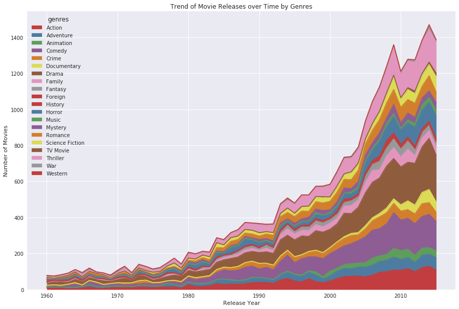

```python
sns.set_style('darkgrid')

# plot data
fig, ax = plt.subplots(figsize=(15,10))

sns.set_palette("Set1", 20, .65)

# use unstack()
df_genres_year.plot.area(ax=ax);
ax.set(xlabel='Release Year', ylabel='Number of Movies', title = 'Trend of Movie Releases over Time by Genres');
```

The popularity of movie released has generally grown over time, from 1960 til around 2015 where the numbers contract slightlty.

### Research Question 6: Which genres have the largest revenue and largest budgets? Which genres are most profitable after working out Return on Investment?

Let's see the mean revenues, budgets for each genre, then plot them in a bar chart to make them easier to analyse

```python
df_new=df_genres[['genres','revenue','budget']].groupby(['genres']).mean()
```

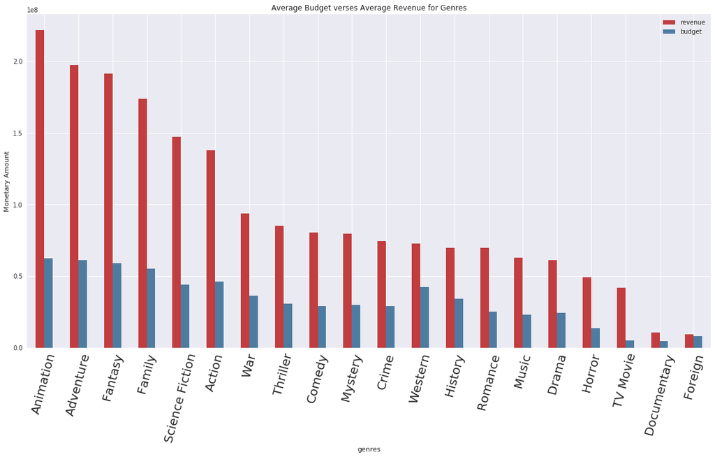

```python
# plot data
f,ax=plt.subplots(figsize=(20, 10))

df_genres[['genres','revenue','budget']].groupby(['genres']).mean().sort_values(["revenue","budget"], ascending=False).plot(kind="bar",  ax=ax);
plt.xticks(rotation=75,fontsize=20)

ax.set(ylabel = 'Monetary Amount', title = 'Average Budget verses Average Revenue for Genres')

plt.show()
```

Looks like we have a better graph sorted list of genres by their average budget and revenue! Animation is a huge earner, and then there is Adventure - but their budget are also higher definitely. That means that in Return on Investment terms, it's less successful? Look at the bottom of the list, Horror, TV Movie, Documentary have less budget compare to their revenue. Are they successfull as well? Let's check it out.

```python
# Create our new dataframe to work on ROI
df_new.head()

# Add a new attribute with the calculated ROI
df_new['ROI'] = df_new['revenue']/df_new['budget']

# confirm
df_new.head(2)
```

| genres | revenue | budget | ROI |
| --- | --- | --- | --- |
| Action | 1.377323e+08 | 4.629070e+07 | 2.975376 |
| Adventure | 1.974209e+08 | 6.095670e+07 | 3.238706 |

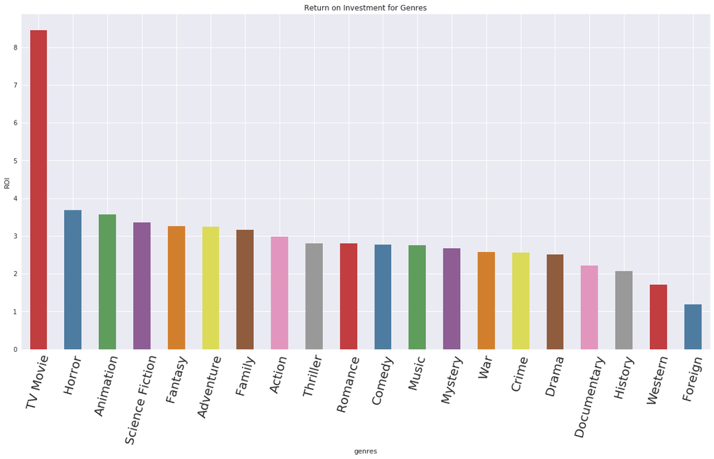

```python
# plot data
# ROI of each genres' movies
f,ax=plt.subplots(figsize=(20, 10))
df_new['ROI'].sort_values(ascending=False).plot(kind="bar",  ax=ax);
plt.xticks(rotation=75,fontsize=20)

ax.set(ylabel = 'ROI', title = 'Return on Investment for Genres')

plt.show()
```

As we can see, TV Movie has less budget compare to the other geners in previous graph. However, its ROI is highest in all genres followed by Horror. They both ar on top of the high ROI genres. It means that they invested less but their revenue is great higher.

## Limitation

1. Units of revenue and budget column: I am not sure that the budgets and revenues all in US dollars? It might be possible different movies have budget in different currency according to the country they were produced. Therefore, a possible inconsistency arises here which can state the incorrect analysis.
2. Data quality: althought I assume the zero values in revenue and budget column are missing, there are still a lot of unreasonable small/big value in the both of the columns.
3. Although the dataset provide the adjusted data for revenue and budget, I only used the revenue and budget data to explore. It might have the inflation effect

## Conclusions

We found that Drama, comedy and thriller were the 3 top most frequent type of movies. The popularity of movie releases has generally grown over time, from 1960 til 2015 where the numbers contract slightlty.

When looking at the success of genres, we analysed a list of genres by their average budget and revenue. It looked like animation is a huge earner, followed by Adventure while foreign movies, documentaries and TV Movies are at the bottom in terms of revenue. If we calculated a return on investment by dividing revenue by budget, TV Movies moved to the top of the RoI analysis results, meaning it earned the most per the amount of budget spent.

```python
from subprocess import call
call(['python', '-m', 'nbconvert', 'Investigate_a_Dataset.ipynb'])
```

```
0
```